# Übungsaufgaben: 2D-Binning

Raphael Schleutker und Hannah Schmitz

Oktober 2017

## Einleitung

### 2D-Binning

In der Aufgabe zu den Osteoklasten haben wir bereits Binning kennengelernt, um die Daten in Form eines Histogramms oder eines Frequenzplots darzustellen. Hierbei wurde eine Variable in sog. Bins unterteilt, und für die Anzahl an Beobachtungen in jedem Bin ein Balken mit der entsprechenden Höhe gezeichnet. Eine darauf aufbauende Möglichkeit ist das 2D-Binning. Hierbei wird nicht eine Variable unterteilt, sondern zwei. Diese werden auf der x- und y-Achse dargestellt. Um die Anzahl an Beobachtungen pro Bin darzustellen, wird in aller Regel eine sequenzielle Farbpalette verwendet, also eine bei der optisch klar erkennbar ist, welche Farbe wenige bzw. viele Beobachtungen darstellt. Theoretisch ist aber auch eine andere Darstellungsweise wie die Transparenz denkbar. Dies geht allerdings mit optischen Problemen einher.

Grundsätzlich können die Bins zwei Formen annehmen: Entweder sind sie schlicht quadratisch, was die einfachere Form darstellt, aber zu optischen Artefakten führen kann. Oder sie sind hexagonal, was unter bestimmten Bedingungen zu einem optisch gefälligeren Ergebnis führt. Beide Varianten sind aber gleichermaßen geeignet, 2D-Bins darzustellen. Um hexagonale Bins nutzen zu können, muss zunächst noch das Paket `hexbin` installiert werden.

### Der Datensatz

In dieser Übungsaufgabe verwenden wir einen FACS-Datensatz. Da FACS-Daten i.d.R. speziell prozessiert werden und es hierfür besondere Software gibt, ist es zugegebenermaßen kein Beispiel für Daten, die man alltäglich mit R visualisiert (auch wenn es spezielle Pakete dafür gibt). Dennoch sind FACS-Daten gut dazu geeignet, das Prinzip von 2D-Binning zu verdeutlichen, da sie meist mehrere hunderttausend Beobachtungen umfassen. Der Bereitgestellte Datensatz umfasst viele Variablen, von denen aber nur der *Forward Scatter (FSC)* und der *Side Scatter (SSC)* dargestellt werden sollen.

Fluoreszenz-Durchflusszytometrie basiert auf einer extrem schmalen Kapillare, durch die in einem Flüssigkeitsstrom vereinzelte Zellen geschickt werden. Hierbei werden die Zellen von verschiedenen Lichtquellen einerseits vermessen, andererseits aber auch zum fluoreszieren angeregt, sofern entsprechende Fluorophore auf der Zelloberfläche vorhanden sind. Für den FSC wird ein Lichtstrahl flach von vorne auf die Zelle gerichtet. Die Streuung des Lichts ist ein Maß für die Größe der Zelle. Für den SSC wird ein Lichtstrahl seitlich im rechten Winkel auf die Zelle gerichtet. Die Streuung des Lichts ist ein Maß für die Oberflächenbeschaffenheit der Zelle. Üblicherweise wird für einen ersten Überblick der FSC auf die x-Achse und der SSC auf die y-Achse gemapped.

## Die Lösungen

### Aufgabe 1

```r
library(readr)
library(dplyr)
FACS <- read_delim("./FACS.csv", "\t", trim_ws = TRUE) %>%
  select(FSC, SSC) %>%
  dplyr::filter(FSC > 1 & SSC > 1)
```

### Aufgabe 2

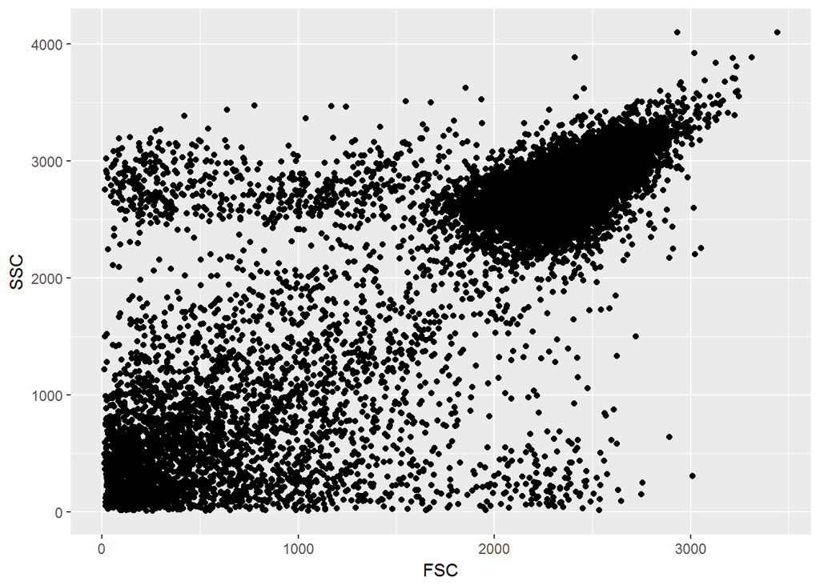

```r
library(ggplot2)

ggplot(FACS, aes(FSC, SSC)) +
  geom_point()
```

### Aufgabe 3

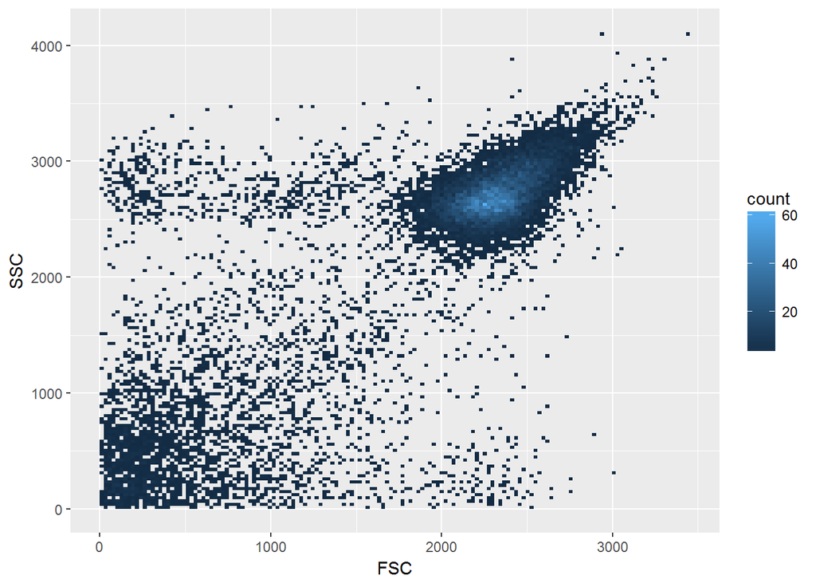

```r
ggplot(FACS, aes(FSC, SSC)) +
  geom_bin2d(bins = 150)
```

### Aufgabe 4

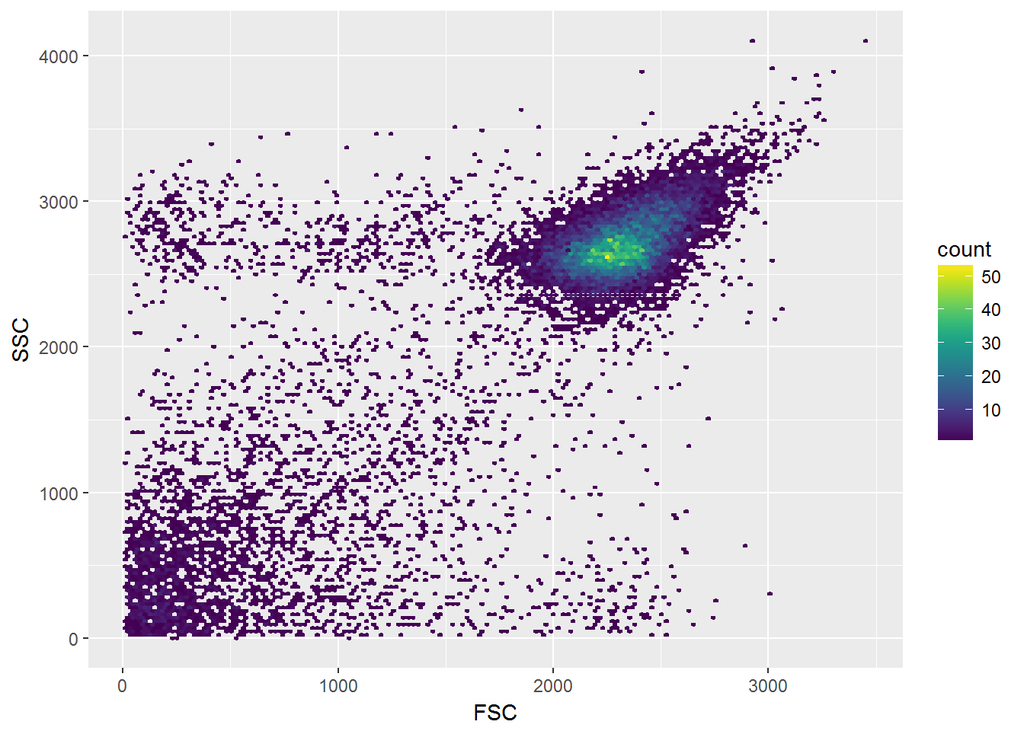

```r
ggplot(FACS, aes(FSC, SSC)) +
  geom_hex(bins = 150) +
  viridis::scale_fill_viridis()
```

### Aufgabe 5

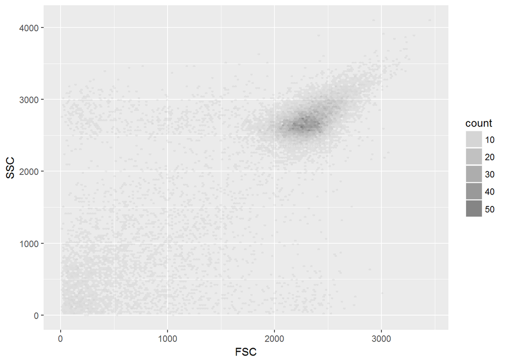

```r
ggplot(FACS, aes(FSC, SSC, alpha = ..count.., fill = NULL)) +
  geom_hex(bins = 150)
```

### Aufgabe 6

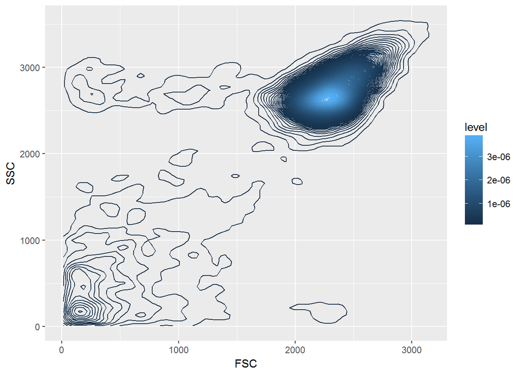

```r
ggplot(FACS, aes(FSC, SSC, colour = ..level..)) +
  geom_density_2d(bins = 150)
```